# Predicting Pancreatic Cancer Aggressiveness

BMIN5030 Final Project

Author

Cameron Cloud

## 1 Overview

This project uses clinical and exposure data from The Cancer Genome Atlas (TCGA-PAAD) to investigate whether non-invasive clinical factors can predict pancreatic tumor aggressiveness. First, I assess relationships between available clinical variables and patient outcomes, confirming that tumor grade is significantly associated with survival time and can serve as a proxy for tumor aggressiveness. I then build predictive models—including logistic regression and random forest classifiers—to determine whether tumor grade can be predicted from non-invasive baseline features such as age, sex, and tumor location. Finally, I incorporate additional exposure variables (e.g., smoking history) to evaluate whether lifestyle factors improve prediction accuracy.

**Main Goal: Determine whether routinely collected, non-invasive clinical factors can predict pancreatic tumor aggressiveness at diagnosis and evaluate whether tumor grade—used as a proxy for aggressiveness—can be predicted from baseline demographic/anatomical/exposure variables**

Two faculty: Dr. Zhou and Dr. Lee (CHOP Pathology Dept and CHOP Center for Computational Genomics), I have learned from Dr. Zhou about cancer biology, and with Dr. Lee’s help, I have been able to focus on certain clinical factors would be most important to use (for clinical convenience and without being redundant) of and what models to make (including how to run a cox model).

[GITHUB LINK](https://github.com/cloudc1/BMIN5030_Final_Project)

## 2 Introduction

The main problem: Pancreatic cancer an aggressive disease, with a five-year survival rate of 44% for local disease, and a 3% for distant disease ([source](https://www.cancer.org/cancer/types/pancreatic-cancer/detection-diagnosis-staging/survival-rates.html)). Exploring whether simple clinical features could aid early risk stratification when more invasive or molecular assays are not available. By building logistic and linear regression models, I hope to identify characteristics that may influence disease aggressiveness. Assessing the predictive value of non-invasive data is important for informing prognosis and potentially supporting clinical decision-making in pancreatic cancer.

This problem is interdisciplinary, consisting of biology/oncology, statistics, and data science. Biology can provide the understanding tumor behavior and treatment effects. Statistics and data science enable interpretation and analysis of large clinical datasets like TCGA. By combining perspectives, this project contributes to a greater understanding of pancreatic cancer prognosis and potential paths toward improving patient outcomes.

## 3 Methods

Packages needed:

```r
library(tidyverse)
library(tidymodels)
library(broom)
library(modelsummary)
library(ggplot2)
library(randomForest)
library(caret)
library(pROC)
library(patchwork)
```

### 3.1 Loading and cleaning main sources of data

```r
#main clinical data
data <- read_tsv("clinical.project-tcga-paad.2025-10-01/clinical.tsv")
dim(data)
```

```
[1] 1082  210
```

```r
#[1] 1082  210

# NOTE: '-- essentially means NA, so converting all those to NA
data[data == "'--"] <- NA

# Get the number of NAs per column
na_counts <- colSums(is.na(data))
#na_counts

#Columns I can focus on -- based on having sufficient data (will get rid of cols if 1000+ NA values)
data <- data[, na_counts < 1000]
#also only interested in patients with primary diagnosis
data <- data |> filter(diagnoses.classification_of_tumor=="primary")
#patients are repeated if they have multiple treatments
data_new <- data |> distinct(cases.case_id, .keep_all = TRUE)
dim(data_new) # 185 patients
```

```
[1] 185  60
```

```r
### Other data I found and decided to do some analyses with to try to imporve predictions
exposure <- read_tsv("clinical.project-tcga-paad.2025-10-01/exposure.tsv")
exposure[exposure == "'--"] <- NA
na_counts <- colSums(is.na(exposure))
exposure <- exposure[, na_counts < nrow(exposure)/2]
```

### 3.2 **Part I. Linear Regression to identify a clinical variable representing aggressiveness (tumor grade associated with days to death)**

```r
# Recoding grade into high and low; limitation is G2 is really an "intermediate" grade, but put with groujp 1
data_new$grade_new <- NA
data_new$grade_new[data_new$diagnoses.tumor_grade %in% c("G1", "G2")] <- "Low"
data_new$grade_new[data_new$diagnoses.tumor_grade %in% c("G3", "G4")] <- "High"

### With help from Dr. Lee !!!
library(survival)
# Needed to account for the patients where there is no days to death. Was told it was risky to impute data for the missing patients because it would introduce bias
data_new$time <- ifelse(
  !is.na(data_new$demographic.days_to_death),
  data_new$demographic.days_to_death,       # event occurred
  data_new$diagnoses.days_to_last_follow_up # censored
)
data_new$event <- ifelse(
  data_new$demographic.vital_status == "Dead",
  1,   # death
  0    # censored/alive
)

surv_obj <- Surv(time = as.numeric(data_new$time), event = data_new$event)
cox_model <- coxph(surv_obj ~ grade_new, data = data_new)
summary(cox_model)
```

```
Call:
coxph(formula = surv_obj ~ grade_new, data = data_new)

  n= 182, number of events= 98
   (3 observations deleted due to missingness)

                coef exp(coef) se(coef)      z Pr(>|z|)
grade_newLow -0.4433    0.6419   0.2129 -2.082   0.0374 *
---
Signif. codes:  0 '***' 0.001 '**' 0.01 '*' 0.05 '.' 0.1 ' ' 1

             exp(coef) exp(-coef) lower .95 upper .95
grade_newLow    0.6419      1.558    0.4229    0.9744

Concordance= 0.558  (se = 0.026 )
Likelihood ratio test= 4.12  on 1 df,   p=0.04
Wald test            = 4.33  on 1 df,   p=0.04
Score (logrank) test = 4.4  on 1 df,   p=0.04
```

```r
sf <- survfit(cox_model, newdata = data.frame(grade_new = c("High", "Low")))
summary(sf)$table
```

```
  records n.max n.start events     rmean se(rmean) median 0.95LCL 0.95UCL
1     182   182     182     98  792.7941  59.57614    511     458     661
2     182   182     182     98 1145.4099 116.08478    661     593    1101
```

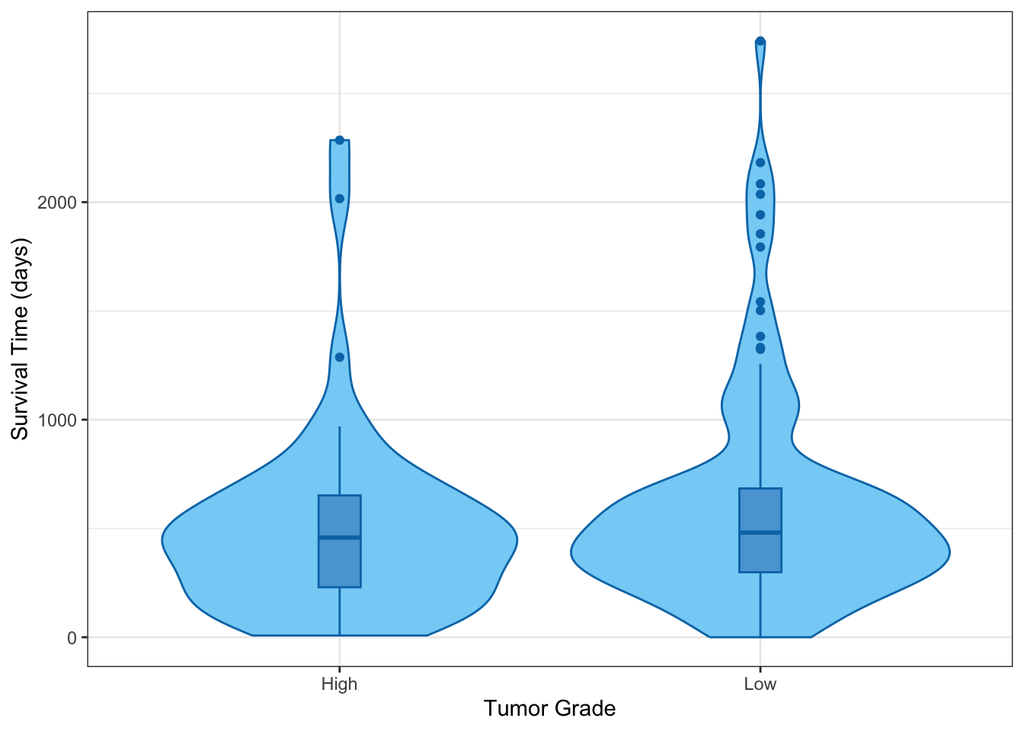

```r
ggplot(
  data_new |> filter(!is.na(grade_new)),   # remove NA grade
  aes(x = grade_new, y = as.numeric(time))
) +
  geom_violin(fill = "#84d2f6", color = "#0077b6", na.rm = TRUE) +
  geom_boxplot(width = 0.1, fill = "#59a5d8", color = "#0077b6", na.rm = TRUE) +
  theme_bw() +
  labs(
    x = "Tumor Grade",       # x-axis label
    y = "Survival Time (days)" # y-axis label
  )
```

```r
# data for modelling
model_data <- data_new[!is.na(data_new$grade_new), ] # removed 3 cases
model_data$grade_new <- factor(model_data$grade_new, levels = c("Low", "High"))
```

High-grade tumors were associated with significantly fewer days to death. Low-grade tumors have a 36% lower hazard of death. Based on survival curve estimates, median survival for low-grade tumors was 661 days compared to 511 for high grade tumors.

### 3.3 Part II: Further exploration of clinical data, followed by univariate logistic regression models to predict tumor grade

Creating/cleaning more for the main data frame for the models

```r
# Recode grade: OUTCOME
model_data$grade_binary <- NA
model_data$grade_binary[model_data$diagnoses.tumor_grade %in% c("G1", "G2")] <- 0
model_data$grade_binary[model_data$diagnoses.tumor_grade %in% c("G3", "G4")] <- 1
model_data$grade_binary <- as.factor(model_data$grade_binary)

# Recode other things: PREDICTORSS
model_data$origin_group <- model_data$diagnoses.tissue_or_organ_of_origin
model_data$origin_group[model_data$origin_group %in%
                        c("Overlapping lesion of pancreas")] <- "Other"
model_data$origin_group <- droplevels(factor(model_data$origin_group))

#make age numeric and by year
model_data$age_years <- as.numeric(as.character(model_data$diagnoses.age_at_diagnosis)) / 365.25
```

Quick tables/plots for study cohort for some context:

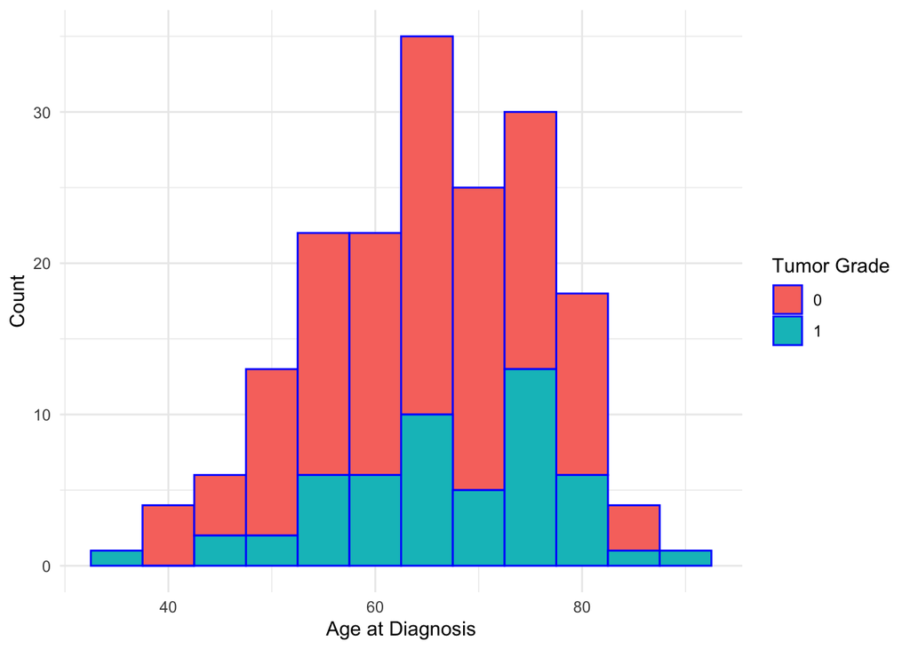

```r
# Age
ggplot(model_data %>% filter(!is.na(age_years)),
       aes(x = age_years, fill = grade_binary)) +
  geom_histogram(binwidth = 5, position = "stack", color = "blue") +
  labs(x = "Age at Diagnosis", y = "Count", fill = "Tumor Grade") +
  theme_minimal()
```

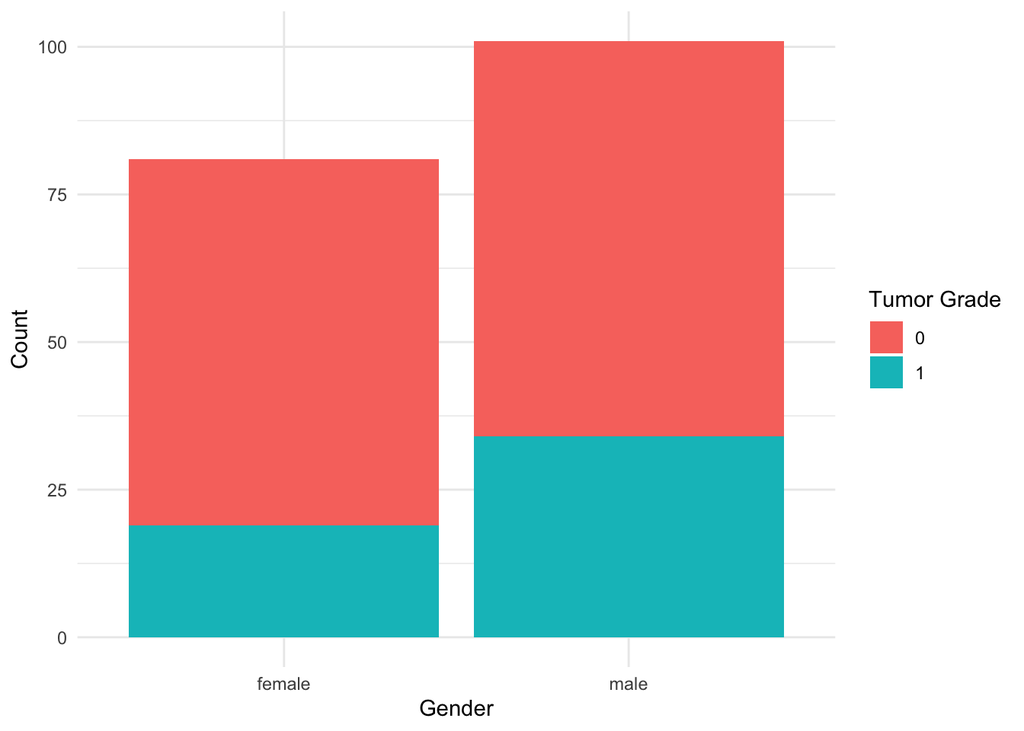

```r
# Gender
ggplot(model_data, aes(x = demographic.gender, fill = grade_binary)) +
  geom_bar(position = "stack") +
  labs(x = "Gender", y = "Count", fill = "Tumor Grade") +
  theme_minimal()
```

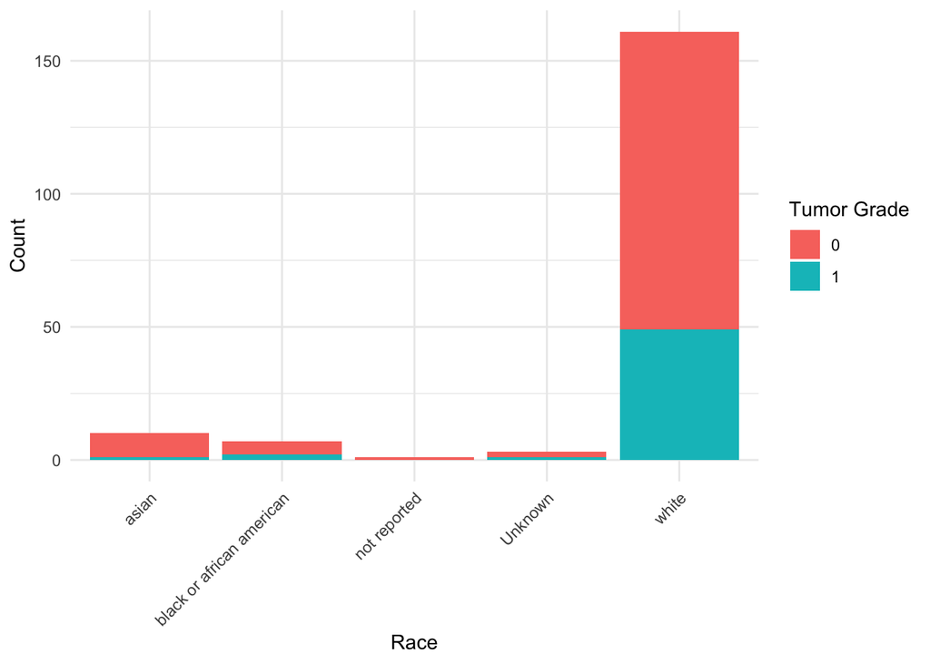

```r
# Race
ggplot(model_data, aes(x = demographic.race, fill = grade_binary)) +
  geom_bar(position = "stack") +
  labs(x = "Race", y = "Count", fill = "Tumor Grade") +
  theme_minimal() +
  theme(axis.text.x = element_text(angle = 45, hjust = 1))
```

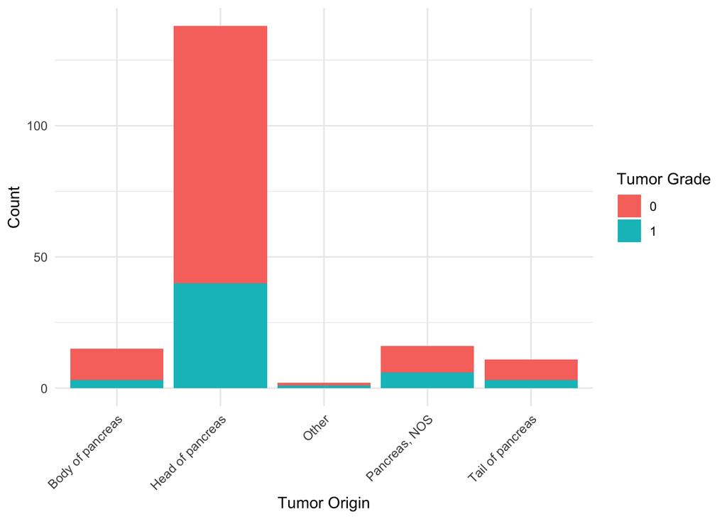

```r
model_data$demographic.race <- as.factor(model_data$demographic.race)
model_data$demographic.race <- relevel(model_data$demographic.race, ref = "white")

# Tumor origin
ggplot(model_data, aes(x = origin_group, fill = grade_binary)) +
  geom_bar(position = "stack") +
  labs(x = "Tumor Origin", y = "Count", fill = "Tumor Grade") +
  theme_minimal() +
  theme(axis.text.x = element_text(angle = 45, hjust = 1))
```

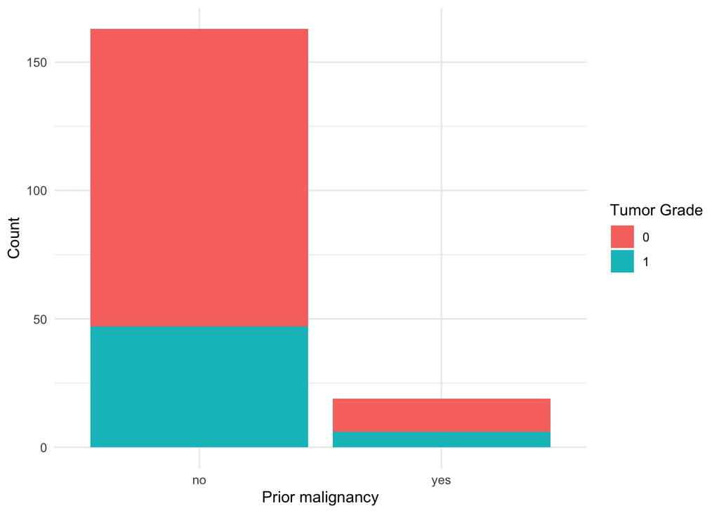

```r
model_data$origin_group <- as.factor(model_data$origin_group)
model_data$origin_group <- relevel(model_data$origin_group, ref = "Head of pancreas")

# Prior malignancy
ggplot(model_data, aes(x = diagnoses.prior_malignancy, fill = grade_binary)) +
  geom_bar(position = "stack") +
  labs(x = "Prior malignancy", y = "Count", fill = "Tumor Grade") +
  theme_minimal()
```

Fitting various univaritiate regression models (identifying candidate predictors). Trying to avoid over-fitting/redundancy/unexpected patterns:

```r
model_age <- glm(grade_binary ~ age_years,
                 data = model_data, family = binomial)
summary(model_age)
```

```
Call:
glm(formula = grade_binary ~ age_years, family = binomial, data = model_data)

Coefficients:
            Estimate Std. Error z value Pr(>|z|)
(Intercept) -2.16666    1.03671  -2.090   0.0366 *
age_years    0.01955    0.01546   1.264   0.2061
---
Signif. codes:  0 '***' 0.001 '**' 0.01 '*' 0.05 '.' 0.1 ' ' 1

(Dispersion parameter for binomial family taken to be 1)

    Null deviance: 218.89  on 180  degrees of freedom
Residual deviance: 217.25  on 179  degrees of freedom
  (1 observation deleted due to missingness)
AIC: 221.25

Number of Fisher Scoring iterations: 4
```

```r
model_gender <- glm(grade_binary ~ demographic.gender,
                    data = model_data, family = binomial)
summary(model_gender)
```

```
Call:
glm(formula = grade_binary ~ demographic.gender, family = binomial,
    data = model_data)

Coefficients:
                       Estimate Std. Error z value Pr(>|z|)
(Intercept)             -1.1827     0.2622   -4.51 6.47e-06 ***
demographic.gendermale   0.5044     0.3363    1.50    0.134
---
Signif. codes:  0 '***' 0.001 '**' 0.01 '*' 0.05 '.' 0.1 ' ' 1

(Dispersion parameter for binomial family taken to be 1)

    Null deviance: 219.58  on 181  degrees of freedom
Residual deviance: 217.28  on 180  degrees of freedom
AIC: 221.28

Number of Fisher Scoring iterations: 4
```

```r
model_race <- glm(grade_binary ~ demographic.race,
                    data = model_data, family = binomial)
summary(model_race)
```

```
Call:
glm(formula = grade_binary ~ demographic.race, family = binomial,
    data = model_data)

Coefficients:
                                           Estimate Std. Error z value Pr(>|z|)
(Intercept)                                -0.82668    0.17128  -4.826 1.39e-06
demographic.raceasian                      -1.37055    1.06792  -1.283    0.199
demographic.raceblack or african american  -0.08961    0.85401  -0.105    0.916
demographic.racenot reported              -13.73939  882.74339  -0.016    0.988
demographic.raceUnknown                     0.13353    1.23666   0.108    0.914

(Intercept)                               ***
demographic.raceasian
demographic.raceblack or african american
demographic.racenot reported
demographic.raceUnknown
---
Signif. codes:  0 '***' 0.001 '**' 0.01 '*' 0.05 '.' 0.1 ' ' 1

(Dispersion parameter for binomial family taken to be 1)

    Null deviance: 219.58  on 181  degrees of freedom
Residual deviance: 216.57  on 177  degrees of freedom
AIC: 226.57

Number of Fisher Scoring iterations: 13
```

```r
model_origin <- glm(grade_binary ~ origin_group,
                    data = model_data, family = binomial)
summary(model_origin)
```

```
Call:
glm(formula = grade_binary ~ origin_group, family = binomial,
    data = model_data)

Coefficients:
                             Estimate Std. Error z value Pr(>|z|)
(Intercept)                  -0.89609    0.18763  -4.776 1.79e-06 ***
origin_groupBody of pancreas -0.49021    0.67221  -0.729    0.466
origin_groupOther             0.89609    1.42661   0.628    0.530
origin_groupPancreas, NOS     0.38526    0.54943   0.701    0.483
origin_groupTail of pancreas -0.08474    0.70252  -0.121    0.904
---
Signif. codes:  0 '***' 0.001 '**' 0.01 '*' 0.05 '.' 0.1 ' ' 1

(Dispersion parameter for binomial family taken to be 1)

    Null deviance: 219.58  on 181  degrees of freedom
Residual deviance: 218.00  on 177  degrees of freedom
AIC: 228

Number of Fisher Scoring iterations: 4
```

```r
model_sick <- glm(grade_binary ~ diagnoses.prior_malignancy,
                    data = model_data, family = binomial)
summary(model_sick)
```

```
Call:
glm(formula = grade_binary ~ diagnoses.prior_malignancy, family = binomial,
    data = model_data)

Coefficients:
                              Estimate Std. Error z value Pr(>|z|)
(Intercept)                    -0.9034     0.1729  -5.225 1.74e-07 ***
diagnoses.prior_malignancyyes   0.1303     0.5230   0.249    0.803
---
Signif. codes:  0 '***' 0.001 '**' 0.01 '*' 0.05 '.' 0.1 ' ' 1

(Dispersion parameter for binomial family taken to be 1)

    Null deviance: 219.58  on 181  degrees of freedom
Residual deviance: 219.51  on 180  degrees of freedom
AIC: 223.51

Number of Fisher Scoring iterations: 4
```

### 3.4 Part III: Multivariate Logistic Regression for odds ratios (see Section 4 for output)

```r
model_multi <- glm(
  grade_binary ~ age_years +
          demographic.gender +
    demographic.race +
      origin_group +
    diagnoses.prior_malignancy,
  data = model_data,
  family = binomial
)
```

### 3.5 **Part IV. Building both multivariate logistic regression and random forest models to predict tumor grade** (see Section 4 for output)

```r
categorical_vars <- c("demographic.gender", "demographic.race",
                      "origin_group", "diagnoses.prior_malignancy")

model_data <- model_data %>%
  mutate(grade_binary = factor(grade_binary, levels = c("0", "1")))

rf_data <- model_data %>%
  dplyr::select(grade_binary, age_years, all_of(categorical_vars)) %>%
  mutate(across(all_of(categorical_vars), ~fct_explicit_na(as.factor(.), na_level = "Unknown"))) %>%
  na.omit()  # remove any remaining NAs in numeric variables
#have to clean because failed bc of some NAs
rf_data$grade_binary <- as.factor(rf_data$grade_binary)

# spitting to train and test
set.seed(1234)
rf_data$grade_binary <- as.factor(rf_data$grade_binary)
data_split <- initial_split(rf_data,
                            strata = grade_binary,
                            prop = 0.70)

data_train <- training(data_split)
data_test <- testing(data_split)

######Logistic regression
lr_cls_spec <-
  logistic_reg() |>
  set_engine("glm")

#Perform 10-fold cross validation on the training data
set.seed(1234)
data_folds <- vfold_cv(data_train, v = 10)

glm_wf <- workflow() |>
  add_model(lr_cls_spec) |>
  add_formula(grade_binary ~ .)

#Use workflow to fit model with each fold of resampled data
glm_fit_cv <-
  glm_wf |>
  fit_resamples(data_folds, control = control_resamples(save_pred = TRUE))
```

```
→ A | warning: prediction from rank-deficient fit; attr(*, "non-estim") has doubtful cases
```

```
There were issues with some computations   A: x2
There were issues with some computations   A: x2
```

```r
#Collect predictions out of folds into one tibble
data_glm_cv_preds <- collect_predictions(glm_fit_cv)

#Plot of ROC curve of CV results
plot1 <- autoplot(roc_curve(data_glm_cv_preds,
        grade_binary,
        .pred_1 ))

collect_metrics(glm_fit_cv)
```

```
# A tibble: 3 × 6
  .metric     .estimator  mean     n std_err .config
  <chr>       <chr>      <dbl> <int>   <dbl> <chr>
1 accuracy    binary     0.715    10  0.0234 pre0_mod0_post0
2 brier_class binary     0.224    10  0.0136 pre0_mod0_post0
3 roc_auc     binary     0.513    10  0.0560 pre0_mod0_post0
```

```r
lr_cls_fit <-
  lr_cls_spec |>
  fit(as.factor(grade_binary) ~ ., data = data_train)

#Prediction on the test data
data.lr.pred.values.test <-  bind_cols(
  truth = data_test$grade_binary,
  predict(lr_cls_fit, data_test),
  predict(lr_cls_fit, data_test, type = "prob")
)

#Plot of ROC curve of prediction on test results
plot2 <- autoplot(roc_curve(data.lr.pred.values.test,
                   truth,
                   .pred_1))
metrics(data.lr.pred.values.test, truth, .pred_class, .pred_1)
```

```
# A tibble: 4 × 3
  .metric     .estimator .estimate
  <chr>       <chr>          <dbl>
1 accuracy    binary        0.691
2 kap         binary       -0.0354
3 mn_log_loss binary        1.83
4 roc_auc     binary        0.534
```

```r
######Random Forest training then testing
rf_spec <- rand_forest(
  mtry = 3,
  trees = 250,
  min_n = 5
) %>%
  set_engine("randomForest", importance = TRUE) %>%
  set_mode("classification")

rf_workflow <-
  workflow() |>
  add_model(rf_spec) |>
  add_formula(grade_binary ~ .)

set.seed(1234)
rf_fit_cv <-
  rf_workflow |>
  fit_resamples(data_folds,
                control = control_resamples(save_pred = TRUE))

collect_metrics(rf_fit_cv)
```

```
# A tibble: 3 × 6
  .metric     .estimator  mean     n std_err .config
  <chr>       <chr>      <dbl> <int>   <dbl> <chr>
1 accuracy    binary     0.666    10  0.0291 pre0_mod0_post0
2 brier_class binary     0.249    10  0.0132 pre0_mod0_post0
3 roc_auc     binary     0.445    10  0.0462 pre0_mod0_post0
```

```r
plot3 <- rf_fit_cv |>
  collect_predictions() |>
  roc_curve(grade_binary, .pred_1) |>
  autoplot()

factor_cols <- c("demographic.gender", "demographic.race",
                 "origin_group", "diagnoses.prior_malignancy")

rf_fit_new <- rf_spec |>
  fit(as.factor(grade_binary) ~ ., data = data_train)

rf_test_preds <- bind_cols(
  truth = data_test$grade_binary,
  predict(rf_fit_new, data_test),
  predict(rf_fit_new, data_test, type = "prob")
)

# ROC curve on test data
plot4 <- autoplot(
  roc_curve(rf_test_preds, truth, .pred_1)
)

metrics(rf_test_preds, truth, .pred_class, .pred_1)
```

```
# A tibble: 4 × 3
  .metric     .estimator .estimate
  <chr>       <chr>          <dbl>
1 accuracy    binary         0.727
2 kap         binary         0.207
3 mn_log_loss binary         1.21
4 roc_auc     binary         0.539
```

### 3.6 Part V: Model with tobacco exposure to see if we get improved predictions

Some cleaning

```r
# need to redefine the smoking groups because some are small. will change NA to unknown
exposure$smoking_group <- dplyr::case_when(
  exposure$exposures.tobacco_smoking_status == "Lifelong Non-Smoker" ~ "Never",
  exposure$exposures.tobacco_smoking_status %in% c(
       "Current Reformed Smoker for < or = 15 yrs",
       "Current Reformed Smoker for > 15 yrs",
       "Current Reformed Smoker, Duration Not Specified"
   ) ~ "Former",
  exposure$exposures.tobacco_smoking_status == "Current Smoker" ~ "Current",
  TRUE ~ "Unknown"
)

exposure_unique <- exposure %>%
  select(cases.case_id, smoking_group) %>%
  distinct(cases.case_id, .keep_all = TRUE)

model_data2 <- model_data %>%
  left_join(exposure_unique, by = "cases.case_id")

model_data2$smoking_group <- as.factor(model_data2$smoking_group)
model_data2$smoking_group <- relevel(model_data2$smoking_group, ref = "Never")


#univariate model
model_smoke <- glm(grade_binary ~ smoking_group,
                 data = model_data2, family = binomial)
summary(model_smoke)
```

```
Call:
glm(formula = grade_binary ~ smoking_group, family = binomial,
    data = model_data2)

Coefficients:
                     Estimate Std. Error z value Pr(>|z|)
(Intercept)           -1.2993     0.3761  -3.455  0.00055 ***
smoking_groupCurrent  -0.8979     1.1191  -0.802  0.42233
smoking_groupFormer    0.5653     0.5145   1.099  0.27190
smoking_groupUnknown   0.6061     0.4357   1.391  0.16413
---
Signif. codes:  0 '***' 0.001 '**' 0.01 '*' 0.05 '.' 0.1 ' ' 1

(Dispersion parameter for binomial family taken to be 1)

    Null deviance: 219.58  on 181  degrees of freedom
Residual deviance: 215.16  on 178  degrees of freedom
AIC: 223.16

Number of Fisher Scoring iterations: 4
```

Adding into multivariate model

```r
model_multi_smoke <- glm(
  grade_binary ~ age_years +
          demographic.gender +
    demographic.race +
      origin_group +
    diagnoses.prior_malignancy +
    smoking_group,
  data = model_data2,
  family = binomial
)
```

Re-running the logistic and random forest prediction models

```r
categorical_vars <- c("demographic.gender", "demographic.race",
                      "origin_group", "diagnoses.prior_malignancy","smoking_group")

model_data2 <- model_data2 %>%
  mutate(grade_binary = factor(grade_binary, levels = c("0", "1")))

rf_data_smoke <- model_data2 %>%
  dplyr::select(grade_binary, age_years, all_of(categorical_vars)) %>%
  mutate(across(all_of(categorical_vars), ~fct_explicit_na(as.factor(.), na_level = "Unknown"))) %>%
  na.omit()  # remove any remaining NAs in numeric variables

#have to clean because failed bc of some NAs
rf_data_smoke$grade_binary <- as.factor(rf_data_smoke$grade_binary)

set.seed(1234)
rf_data_smoke$grade_binary <- as.factor(rf_data_smoke$grade_binary)
data_split <- initial_split(rf_data_smoke,
                            strata = grade_binary,
                            prop = 0.70)

data_train <- training(data_split)
data_test <- testing(data_split)


######Logistic regression: might not be the best model for this data with this small sample size
lr_cls_spec <-
  logistic_reg() |>
  set_engine("glm")

#Perform 10-fold cross validation on the training data
set.seed(1234)
data_folds <- vfold_cv(data_train, v = 10)

glm_wf <- workflow() |>
  add_model(lr_cls_spec) |>
  add_formula(grade_binary ~ .)

#Use workflow to fit model with each fold of resampled data
glm_fit_cv <-
  glm_wf |>
  fit_resamples(data_folds, control = control_resamples(save_pred = TRUE))
```

```
→ A | warning: glm.fit: fitted probabilities numerically 0 or 1 occurred
```

```
There were issues with some computations   A: x1
```

```
→ B | warning: prediction from rank-deficient fit; attr(*, "non-estim") has doubtful cases
```

```
There were issues with some computations   A: x1
There were issues with some computations   A: x10   B: x2
```

```r
#Collect predictions out of folds into one tibble
data_glm_cv_preds <- collect_predictions(glm_fit_cv)

#Plot of ROC curve of CV results
plot1_smoke <- autoplot(roc_curve(data_glm_cv_preds,
        grade_binary,
        .pred_1 ))

collect_metrics(glm_fit_cv)
```

```
# A tibble: 3 × 6
  .metric     .estimator  mean     n std_err .config
  <chr>       <chr>      <dbl> <int>   <dbl> <chr>
1 accuracy    binary     0.691    10  0.0244 pre0_mod0_post0
2 brier_class binary     0.238    10  0.0171 pre0_mod0_post0
3 roc_auc     binary     0.525    10  0.0555 pre0_mod0_post0
```

```r
lr_cls_fit <-
  lr_cls_spec |>
  fit(as.factor(grade_binary) ~ ., data = data_train)
#Prediction on the test data
data.lr.pred.values.test <-  bind_cols(
  truth = data_test$grade_binary,
  predict(lr_cls_fit, data_test),
  predict(lr_cls_fit, data_test, type = "prob")
)

#Plot of ROC curve of prediction on test results
plot2_smoke <- autoplot(roc_curve(data.lr.pred.values.test,
                   truth,
                   .pred_1))
metrics(data.lr.pred.values.test, truth, .pred_class, .pred_1)
```

```
# A tibble: 4 × 3
  .metric     .estimator .estimate
  <chr>       <chr>          <dbl>
1 accuracy    binary         0.709
2 kap         binary         0
3 mn_log_loss binary         2.41
4 roc_auc     binary         0.562
```

```r
######Random Forest training then testing
rf_spec <- rand_forest(
  mtry = 3,
  trees = 250,
  min_n = 5
) %>%
  set_engine("randomForest", importance = TRUE) %>%
  set_mode("classification")

rf_workflow <-
  workflow() |>
  add_model(rf_spec) |>
  add_formula(grade_binary ~ .)

set.seed(1234)
rf_fit_cv <-
  rf_workflow |>
  fit_resamples(data_folds,
                control = control_resamples(save_pred = TRUE))

collect_metrics(rf_fit_cv)
```

```
# A tibble: 3 × 6
  .metric     .estimator  mean     n std_err .config
  <chr>       <chr>      <dbl> <int>   <dbl> <chr>
1 accuracy    binary     0.691    10  0.0269 pre0_mod0_post0
2 brier_class binary     0.244    10  0.0161 pre0_mod0_post0
3 roc_auc     binary     0.464    10  0.0529 pre0_mod0_post0
```

```r
plot3_smoke <- rf_fit_cv |>
  collect_predictions() |>
  roc_curve(grade_binary, .pred_1) |>
  autoplot()

rf_fit_new <- rf_spec |>
  fit(as.factor(grade_binary) ~ ., data = data_train)
factor_cols <- c("demographic.gender", "demographic.race",
                 "origin_group", "diagnoses.prior_malignancy")


rf_test_preds <- bind_cols(
  truth = data_test$grade_binary,
  predict(rf_fit_new, data_test),
  predict(rf_fit_new, data_test, type = "prob")
)

# ROC curve on test data
plot4_smoke <- autoplot(
  roc_curve(rf_test_preds, truth, .pred_1)
)

metrics(rf_test_preds, truth, .pred_class, .pred_1)
```

```
# A tibble: 4 × 3
  .metric     .estimator .estimate
  <chr>       <chr>          <dbl>
1 accuracy    binary         0.764
2 kap         binary         0.281
3 mn_log_loss binary         1.19
4 roc_auc     binary         0.517
```

## 4 Results

We first examined univariate logistic regression models for each clinical variable to identify potential predictors of high-grade tumors and to understand their individual associations. This approach informs variable selection for the subsequent multivariate model and helps avoid overfitting. After this, we performed multivariate logistic regression to predict tumor grade, with odds ratios and relevant plots below:

```r
summary(model_multi)
```

```
Call:
glm(formula = grade_binary ~ age_years + demographic.gender +
    demographic.race + origin_group + diagnoses.prior_malignancy,
    family = binomial, data = model_data)

Coefficients:
                                          Estimate Std. Error z value Pr(>|z|)
(Intercept)                               -2.27985    1.12663  -2.024    0.043
age_years                                  0.01765    0.01663   1.061    0.289
demographic.gendermale                     0.47910    0.34259   1.398    0.162
demographic.raceasian                     -1.10274    1.08445  -1.017    0.309
demographic.raceblack or african american -0.06549    0.88193  -0.074    0.941
demographic.raceUnknown                    0.13674    1.29609   0.106    0.916
origin_groupBody of pancreas              -0.47038    0.68660  -0.685    0.493
origin_groupOther                          1.09740    1.46728   0.748    0.455
origin_groupPancreas, NOS                  0.35864    0.58208   0.616    0.538
origin_groupTail of pancreas              -0.11422    0.72051  -0.159    0.874
diagnoses.prior_malignancyyes             -0.04359    0.55837  -0.078    0.938

(Intercept)                               *
age_years
demographic.gendermale
demographic.raceasian
demographic.raceblack or african american
demographic.raceUnknown
origin_groupBody of pancreas
origin_groupOther
origin_groupPancreas, NOS
origin_groupTail of pancreas
diagnoses.prior_malignancyyes
---
Signif. codes:  0 '***' 0.001 '**' 0.01 '*' 0.05 '.' 0.1 ' ' 1

(Dispersion parameter for binomial family taken to be 1)

    Null deviance: 218.89  on 180  degrees of freedom
Residual deviance: 211.96  on 170  degrees of freedom
  (1 observation deleted due to missingness)
AIC: 233.96

Number of Fisher Scoring iterations: 4
```

```r
or_table <- tidy(model_multi, exponentiate = TRUE, conf.int = TRUE)
or_table
```

```
# A tibble: 11 × 7
   term                  estimate std.error statistic p.value conf.low conf.high
   <chr>                    <dbl>     <dbl>     <dbl>   <dbl>    <dbl>     <dbl>
 1 (Intercept)              0.102    1.13     -2.02    0.0430   0.0103     0.878
 2 age_years                1.02     0.0166    1.06    0.289    0.986      1.05
 3 demographic.genderma…    1.61     0.343     1.40    0.162    0.832      3.20
 4 demographic.raceasian    0.332    1.08     -1.02    0.309    0.0175     1.93
 5 demographic.raceblac…    0.937    0.882    -0.0743  0.941    0.126      4.77
 6 demographic.raceUnkn…    1.15     1.30      0.106   0.916    0.0486    13.6
 7 origin_groupBody of …    0.625    0.687    -0.685   0.493    0.134      2.17
 8 origin_groupOther        3.00     1.47      0.748   0.455    0.111     81.7
 9 origin_groupPancreas…    1.43     0.582     0.616   0.538    0.434      4.41
10 origin_groupTail of …    0.892    0.721    -0.159   0.874    0.183      3.39
11 diagnoses.prior_mali…    0.957    0.558    -0.0781  0.938    0.299      2.76
```

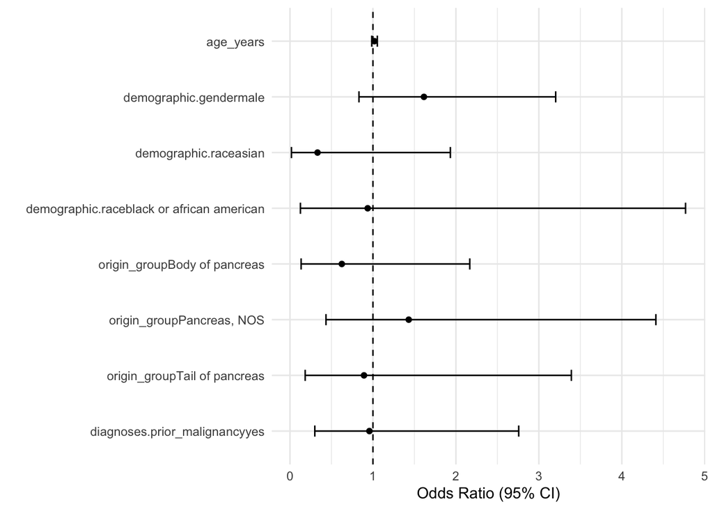

```r
or_table_plot <- or_table %>%
  filter(term != "(Intercept)", term != "origin_groupOther",term != "demographic.raceUnknown") %>% # didnt plot the Other groups for visibility of other categories (large std.error)
  mutate(term = factor(term, levels = rev(term))) # reverse for top-down plotting

# Forest plot of odds ratios
ggplot(or_table_plot, aes(x = estimate, y = term)) +
  geom_point() +
  geom_errorbarh(aes(xmin = conf.low, xmax = conf.high), height = 0.2) +
  geom_vline(xintercept = 1, linetype = "dashed") +  # OR=1 reference
  xlab("Odds Ratio (95% CI)") +
  ylab("") +
  theme_minimal()
```

```r
summary(model_multi_smoke)
```

```
Call:
glm(formula = grade_binary ~ age_years + demographic.gender +
    demographic.race + origin_group + diagnoses.prior_malignancy +
    smoking_group, family = binomial, data = model_data2)

Coefficients:
                                          Estimate Std. Error z value Pr(>|z|)
(Intercept)                               -2.44829    1.20508  -2.032   0.0422
age_years                                  0.01552    0.01687   0.920   0.3576
demographic.gendermale                     0.38102    0.34910   1.091   0.2751
demographic.raceasian                     -0.91961    1.09801  -0.838   0.4023
demographic.raceblack or african american -0.01829    0.90536  -0.020   0.9839
demographic.raceUnknown                    0.76857    1.38015   0.557   0.5776
origin_groupBody of pancreas              -0.43953    0.69125  -0.636   0.5249
origin_groupOther                          0.86899    1.47387   0.590   0.5555
origin_groupPancreas, NOS                  0.33356    0.59155   0.564   0.5728
origin_groupTail of pancreas              -0.21546    0.73050  -0.295   0.7680
diagnoses.prior_malignancyyes              0.09983    0.58881   0.170   0.8654
smoking_groupCurrent                      -0.92674    1.17030  -0.792   0.4284
smoking_groupFormer                        0.46377    0.54277   0.854   0.3929
smoking_groupUnknown                       0.51717    0.46080   1.122   0.2617

(Intercept)                               *
age_years
demographic.gendermale
demographic.raceasian
demographic.raceblack or african american
demographic.raceUnknown
origin_groupBody of pancreas
origin_groupOther
origin_groupPancreas, NOS
origin_groupTail of pancreas
diagnoses.prior_malignancyyes
smoking_groupCurrent
smoking_groupFormer
smoking_groupUnknown
---
Signif. codes:  0 '***' 0.001 '**' 0.01 '*' 0.05 '.' 0.1 ' ' 1

(Dispersion parameter for binomial family taken to be 1)

    Null deviance: 218.89  on 180  degrees of freedom
Residual deviance: 208.93  on 167  degrees of freedom
  (1 observation deleted due to missingness)
AIC: 236.93

Number of Fisher Scoring iterations: 4
```

```r
or_table_smoke <- tidy(model_multi_smoke, exponentiate = TRUE, conf.int = TRUE)
or_table_smoke
```

```
# A tibble: 14 × 7
   term                  estimate std.error statistic p.value conf.low conf.high
   <chr>                    <dbl>     <dbl>     <dbl>   <dbl>    <dbl>     <dbl>
 1 (Intercept)             0.0864    1.21     -2.03    0.0422  0.00746     0.861
 2 age_years               1.02      0.0169    0.920   0.358   0.983       1.05
 3 demographic.genderma…   1.46      0.349     1.09    0.275   0.743       2.94
 4 demographic.raceasian   0.399     1.10     -0.838   0.402   0.0207      2.42
 5 demographic.raceblac…   0.982     0.905    -0.0202  0.984   0.127       5.28
 6 demographic.raceUnkn…   2.16      1.38      0.557   0.578   0.0828     31.4
 7 origin_groupBody of …   0.644     0.691    -0.636   0.525   0.138       2.26
 8 origin_groupOther       2.38      1.47      0.590   0.555   0.0872     65.4
 9 origin_groupPancreas…   1.40      0.592     0.564   0.573   0.415       4.38
10 origin_groupTail of …   0.806     0.730    -0.295   0.768   0.163       3.13
11 diagnoses.prior_mali…   1.10      0.589     0.170   0.865   0.329       3.42
12 smoking_groupCurrent    0.396     1.17     -0.792   0.428   0.0189      2.88
13 smoking_groupFormer     1.59      0.543     0.854   0.393   0.552       4.72
14 smoking_groupUnknown    1.68      0.461     1.12    0.262   0.698       4.33
```

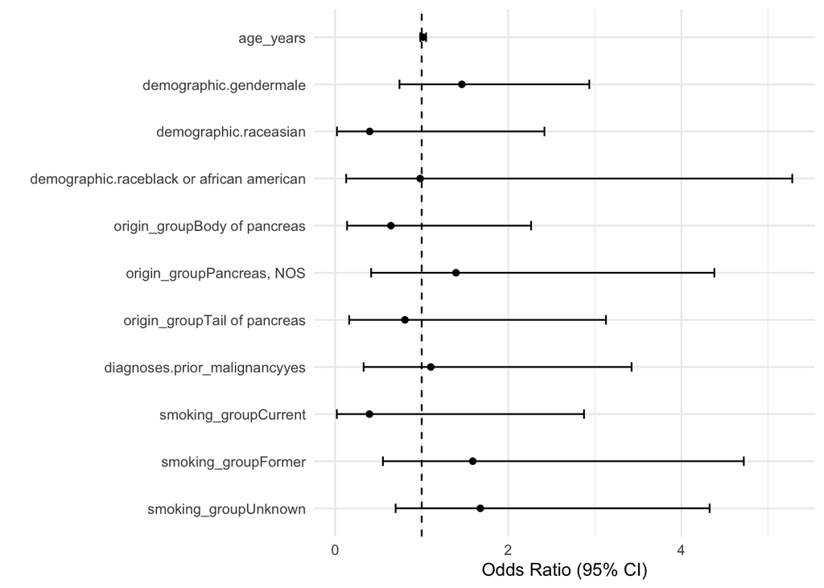

```r
or_table_plot_smoke <- or_table_smoke %>%
  filter(term != "(Intercept)", term != "origin_groupOther",term != "demographic.raceUnknown") %>% # didnt plot the Other group for visibility of other categories
  mutate(term = factor(term, levels = rev(term))) # reverse for top-down plotting

# Forest plot of odds ratios
ggplot(or_table_plot_smoke, aes(x = estimate, y = term)) +
  geom_point() +
  geom_errorbarh(aes(xmin = conf.low, xmax = conf.high), height = 0.2) +
  geom_vline(xintercept = 1, linetype = "dashed") +  # OR=1 reference
  xlab("Odds Ratio (95% CI)") +
  ylab("") +
  theme_minimal()
```

Nothing significant from the table of odds ratios. The addition of smoking didn’t improve much. Regarding sex, males have **slightly higher odds** of high tumor grade compared to females. “**Evidence suggests males often have worse pancreatic cancer outcomes**, with higher incidence and mortality rates…” [Source](https://www.frontiersin.org/journals/oncology/articles/10.3389/fonc.2022.839779/full#:~:text=Also%2C%20worse%20survival%20has%20been,treatment%20in%20metastatic%20pancreatic%20cancer).

### 4.1 Prediction models result

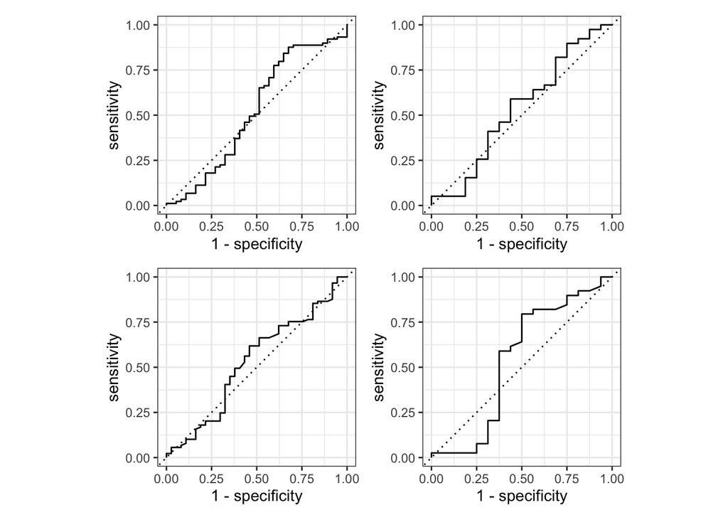

```r
# without smoking
# TOP IS LOGISTIC TRAIN - TEST
# TOP IS RANDOM FOREST TRAIN - TEST
(plot1 | plot2) / (plot3 | plot4)
```

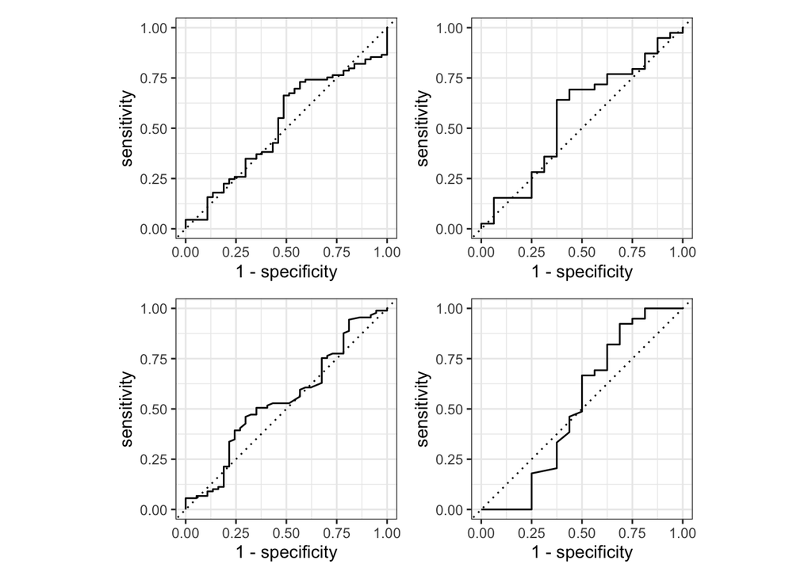

```r
# with smoking
# TOP IS LOGISTIC TRAIN - TEST
# TOP IS RANDOM FOREST TRAIN - TEST
(plot1_smoke | plot2_smoke) / (plot3_smoke | plot4_smoke)
```

Very poor, can see AUC’s in Section 3 are consistent with the plots. Both logistic and random forest do poorly. However, if I were to do this again, I would just stick with random forest. Got some errors in the methods section.

## 5 Conclusion

Tumor grade is okay to use as a proxy for aggressiveness because we see in the initial linear cox regression that high-grade tumors were associated with significantly fewer days to death. Specifically, low-grade tumors have a 36% lower hazard of death. Based on survival curve estimates, median survival for low-grade tumors was 661 days compared to 511 for high grade tumors.

The ROC curves show that the models provide little to no discriminative ability for predicting tumor grade from the available non-invasive clinical variables. Both curves lie close to the diagonal, indicating performance no better than random classification. The addition of smoking status to the model did not meaningfully improve predictive ability, and all variables remained non-significant, suggesting that routinely collected baseline clinical factors alone may have limited utility for predicting tumor aggressiveness in this cohort. This suggests that the predictors in our dataset do not contain sufficient signal to distinguish tumor grades reliably. Overall, non-invasive clinical variables obtained before diagnosis appear inadequate for accurate tumor-grade prediction in this cohort. Wee may have to always take into account pathology and/or molecular characteristics in order to make any conclusions about tumor grade.